# Project 2: Modelling daily cycling demand in Edinburgh

Group members: [Karthik Sutheeshkumar], [Kiet Lam], [Leon]

# Introduction

Edinburgh operates a network of automatic cycling counters at strategic locations across the city that records the total number of cyclists passing each sit daily, The resulting dataset contains 2,180 observations spanning from 2020 to 2025, covering a period that includes the COVID-19 pandemic and a gradual return to normal travel patterns. Using this data, we evaluate a sequence of linear regression models of increasing complexity rigorously to explain how daily cycling demand varies with weather conditions, day of week, seasonality, and longer-term trend, evaluating each model using leave-one-year-out cross validation. The analysis is guided by three questions of practical interest to Edinburgh City Council: how well the model predicts demand across different seasons, how sensitive cycling is to temperature, and what the long-term trend implies for infrastructure planning over the next decade.

# Exploratory data analysis

**Summary statistics table**

Summary statistics for daily cyclist count and temperature variables.

| Variable | Mean | SD | Min | Median | Max |
| --- | --- | --- | --- | --- | --- |
| Daily Count | 10815.5 | 4728.9 | 1264.0 | 10531.0 | 43864 |
| Mean Temp (°C) | 9.7 | 4.8 | -8.1 | 9.8 | 23 |
| Min Temp (°C) | 5.9 | 5.0 | -14.0 | 6.0 | 18 |
| Max Temp (°C) | 13.2 | 5.3 | -3.0 | 13.0 | 31 |

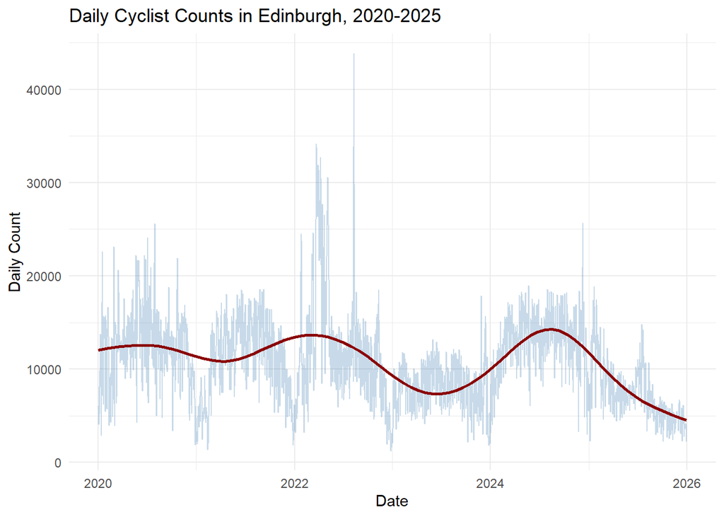

Time series of daily cyclist counts in Edinburgh (2020–2025) with a smoother.

**Boxplots of count by month and by day of week**

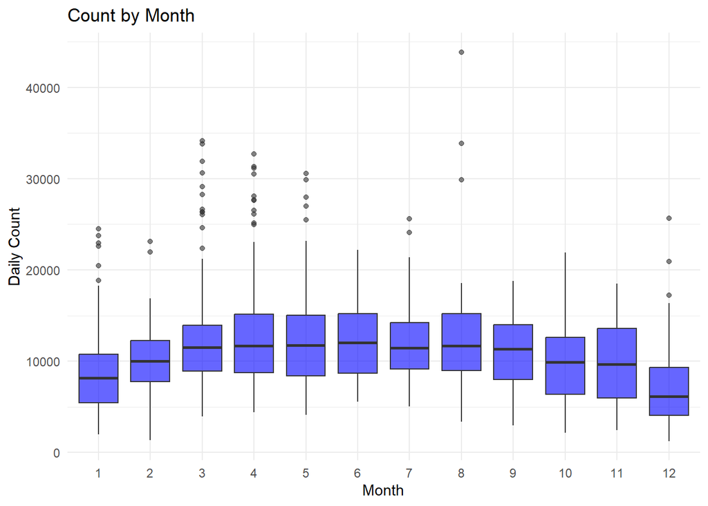

The boxplot by month confirms the seasonal pattern seen in the time series. Counts are lowest in January and December, with medians around 7,000-8,000 cyclists per day, rising steadily through spring and peaking between May and August. Winter months see roughly half the cycling activity of summer months, which has clear implications for seasonal infrastructure planning.

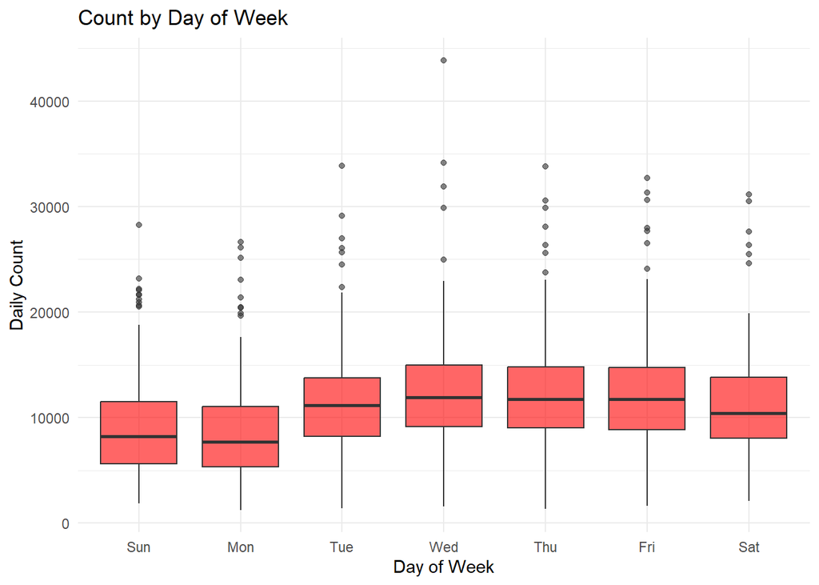

Cycling demand is noticeably higher on weekdays than weekends, with Tuesday to Friday showing the highest medians of around 11,000-12,000 cyclists per day. Sunday and Monday stand out as the lowest, with medians closer to 8,000-9,000, suggesting that commuting is a major driver of cycling demand in Edinburgh.

**Scatter plot of count vs temp_mean**

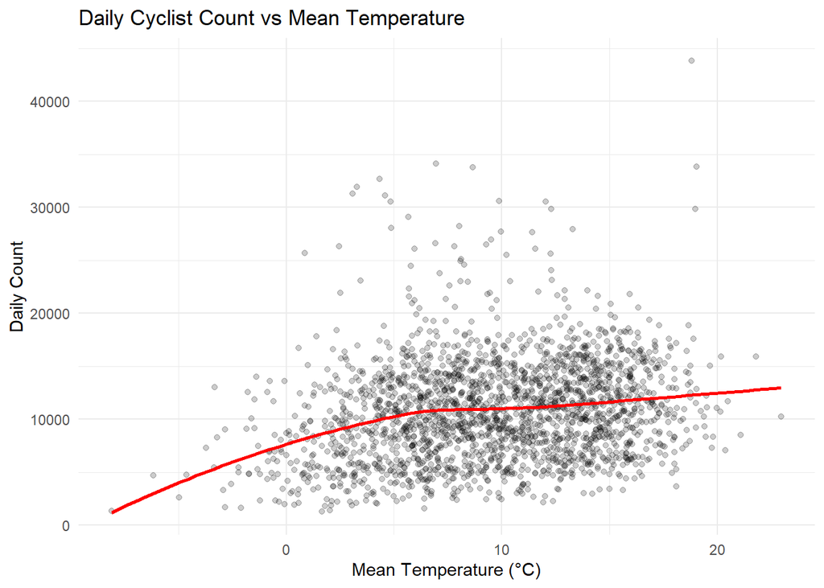

The above figure shows a clear positive but non-linear relationship between mean temperature and daily cyclist counts. Counts rise steeply at lower temperatures before leveling off above around 10–12°C, motivating the quadratic temperature term used in M2 and M3. The spread of counts also increases with temperature, suggesting heteroscedasticity and supporting the log-transform applied in M3.

**Showing relation between count and mean temperature during COVID and post COVID period**

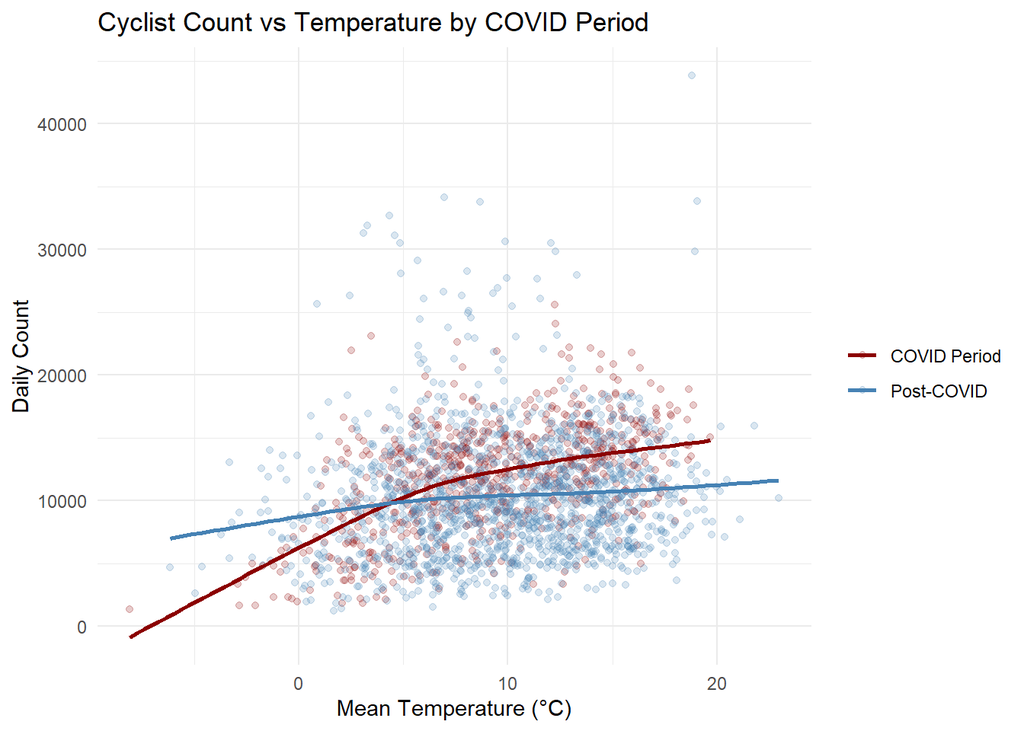

# Baseline model M0

Coefficient table for baseline model M0.

| term | estimate | std.error | statistic | p.value |
| --- | --- | --- | --- | --- |
| (Intercept) | 10385.819 | 267.015 | 38.90 | 0 |
| temp_mean | 247.179 | 20.769 | 11.90 | 0 |
| weekend | -1246.888 | 214.172 | -5.82 | 0 |
| month_num | -247.184 | 28.810 | -8.58 | 0 |

Table shows the estimated coefficients for M0. All four predictors are highly significant (p < 0.001). Each 1°C increase in mean temperature is associated with approximately 247 additional cyclists per day, while weekend days see around 1,247 fewer cyclists than weekdays, consistent with the commuter-driven pattern observed in the EDA. The negative month coefficient (-247) implies that counts decline on average as the month number increases, though this is a crude approximation since the relationship between month and demand is not linear.

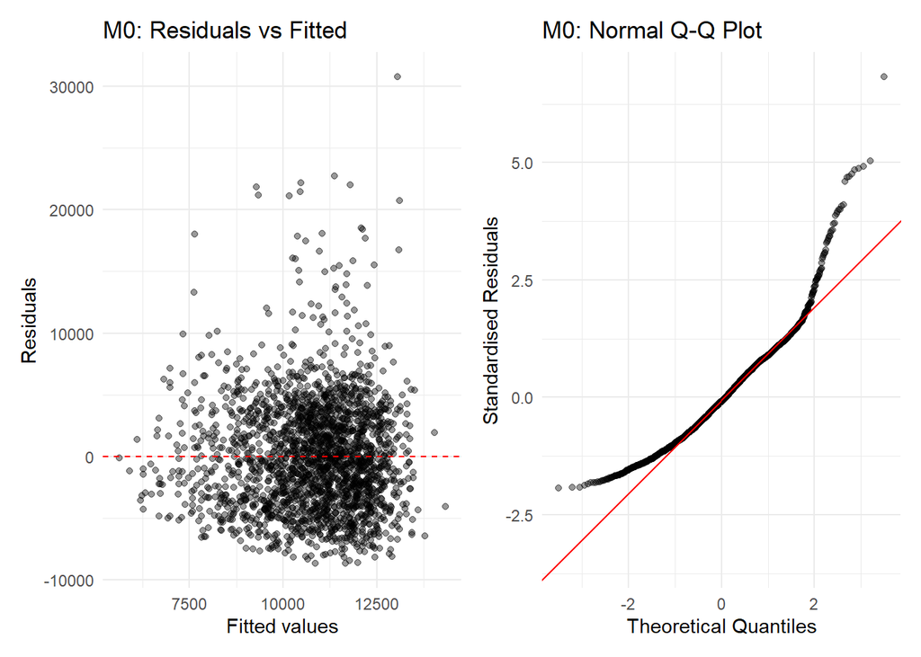

The residuals versus fitted plot shows that the spread of residuals grows noticeably with fitted values, indicating heteroscedasticity — a violation of the constant variance assumption. The QQ plot reveals a heavy right tail, with standardised residuals curving sharply above the reference line at high quantiles, reflecting the right-skewed distribution typical of non-negative count data. Both issues suggest that M0’s Gaussian assumption is inadequate.

M0 captures the broad direction of key predictors — temperature, weekend effect, and seasonality but treats month as numeric, forcing a linear relationship across months that does not reflect the true seasonal pattern seen in the EDA. It also omits day of week entirely and includes no long-term trend. These limitations motivate M1, which switches month to a factor, adds day of week as a factor, and introduces a linear trend term to capture drift in cycling demand over 2020–2025.

# Proposed models M1–M3

## Model M1: Trend and factor

$$\text{count}_i = \beta_0
+ \beta_1 \cdot \text{temp_mean}_i
+ \beta_2 \cdot \text{weekend}_i
+ \beta_3 \cdot \text{trend}_i
+ \sum_{m=2}^{12} \gamma_m \cdot \mathbf{1}(\text{month}_i = m)
+ \sum_{d=2}^{7} \delta_d \cdot \mathbf{1}(\text{dow}_i = d)
+ \varepsilon_i, \quad \varepsilon_i \sim N(0, \sigma^2)$$

M1 extends the baseline model in three ways, each motivated by clear limitations identified in M0.

First, month is switched from a numeric predictor to a factor, giving each month its own intercept. The boxplot in Figure 2 shows that the relationship between month and demand is not monotonic — counts peak in summer and fall in winter but do not follow a straight line across month numbers 1 to 12, so forcing a single slope as M0 does is inappropriate.

Second, day of week is added as a factor. The boxplot in Figure 3 showed a clear difference between weekdays and weekends, but the weekend binary in M0 groups Saturday and Sunday together. Since Saturday behaves differently from Sunday — likely reflecting a mix of leisure and residual commuting trips — a full factor allows each day to have its own effect.

Third, a linear trend term is added, defined as the number of days since 1 January 2020. The time series in Figure 1 suggests that underlying demand has shifted over the 2020–2025 period, and without a trend term the model has no way to capture this drift, potentially biasing all other coefficient estimates

Diagnostics of m1

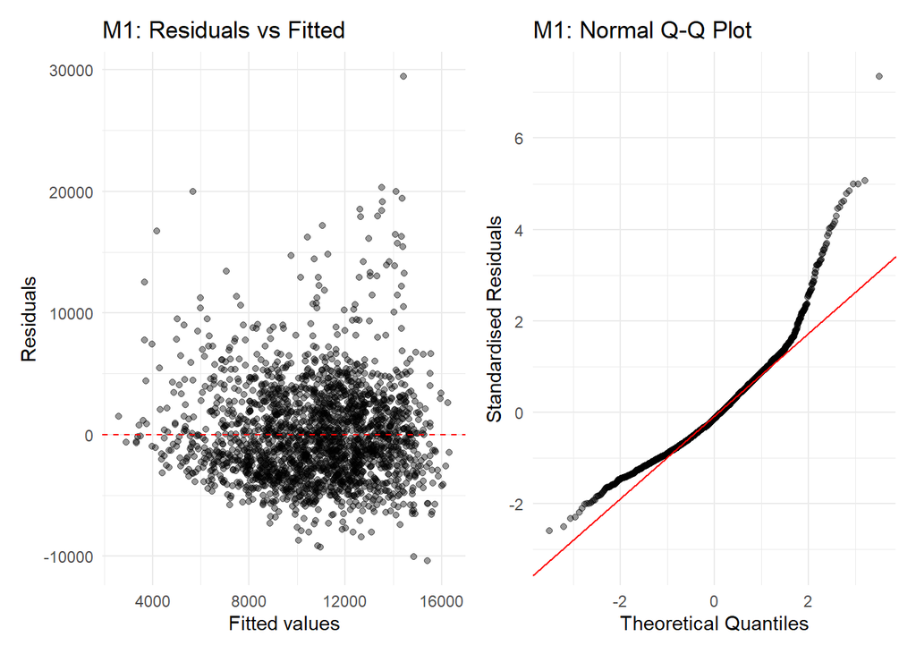

Compared to M0, M1 shows some improvement — the fitted values span a wider range, suggesting the additional predictors (trend, factor month, factor day of week) give the model more flexibility to capture variation in demand. However, the core issues persist. The residuals versus fitted plot still shows increasing spread at higher fitted values, indicating heteroscedasticity remains unresolved. The QQ plot continues to show a pronounced right tail, with standardized residuals reaching above 6 at the upper end, reflecting the right-skewed nature of the count data that a Gaussian model struggles to accommodate. These issues motivate further extensions in M2 and M3.

## Model M2: Nonlinear temperature

$$\text{count}_i = \beta_0
+ \beta_1 \cdot \text{temp_mean}_i
+ \beta_2 \cdot \text{temp_mean}^2_i
+ \beta_3 \cdot \text{weekend}_i
+ \beta_4 \cdot \text{trend}_i
+ \sum_{m=2}^{12} \gamma_m \cdot \mathbf{1}(\text{month}_i = m)
+ \sum_{d=2}^{7} \delta_d \cdot \mathbf{1}(\text{dow}_i = d)
+ \varepsilon_i, \quad \varepsilon_i \sim N(0, \sigma^2)$$

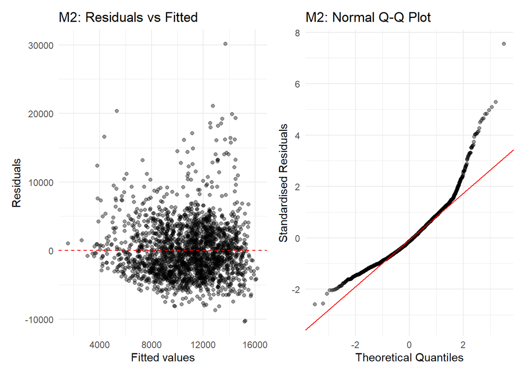

M2 shows marginal improvement over M1 — the residuals versus fitted plot appears slightly more evenly spread, suggesting the quadratic temperature term has captured some additional structure in the data. The lower tail of the QQ plot also follows the reference line more closely than in M1. However, the right tail remains heavily skewed, with standardised residuals exceeding 7 at the upper end, worse than M1. Heteroscedasticity also persists, with residual spread still growing at higher fitted values. The consistently heavy right tail across M0, M1, and M2 strongly suggests that a Gaussian model is fundamentally inappropriate for these count data, and motivates the log transformation of the response in M3.

## Model M3: [Log-Transformed Response]

M3 keeps all predictors from M2 but log-transforms the response variable, fitting log(count + 1) rather than count directly. The diagnostic plots for M0, M1, and M2 consistently showed two problems: a heavy right tail in the QQ plot and residual spread increasing with fitted values. Both are classic symptoms of right-skewed, non-negative count data being modelled with a Gaussian assumption. The log transformation directly addresses this — by compressing large values, it reduces skewness in the response and stabilises variance, making the Gaussian assumption more plausible. The +1 is added before taking the log to handle any zero counts, since log(0) is undefined.

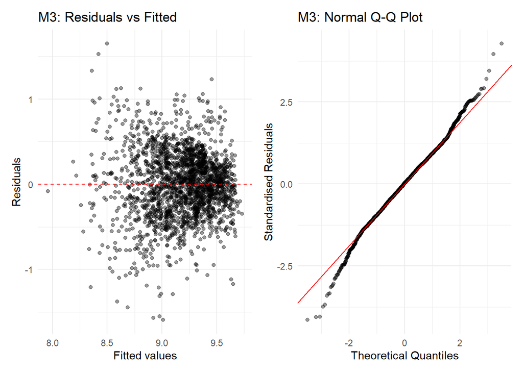

The diagnostic plots for M3 show a marked improvement over all previous models. The residuals versus fitted plot no longer shows the growing spread seen in M0 through M2 — residuals are now scattered fairly evenly around zero across the full range of fitted values, suggesting the log transformation has largely resolved the heteroscedasticity. The QQ plot is dramatically better, with standardised residuals following the reference line closely across almost the entire range, compared to the severe right tail deviation seen in M2 where residuals exceeded 7. The tails still deviate slightly at both ends, indicating some remaining non-normality, but this is a substantial improvement. Overall, the log transformation successfully addressed the two core issues identified in M0 through M2 — right skew and non-constant variance — making the Gaussian assumption considerably more plausible for M3 than for any of the earlier models.

# Evaluation

## Statistical Performance

Table 1. Leave-one-year-out cross-validation scores for models M0–M3. Lower is better for all scores.

| model | RMSE | MAE | DS | IS |
| --- | --- | --- | --- | --- |
| M0 | 4740.9 | 3805.6 | 18.05 | 25630.5 |
| M1 | 4602.3 | 3665.3 | 18.08 | 25391.0 |
| M2 | 4587.6 | 3650.2 | 18.07 | 25277.9 |
| M3 | 4530.8 | 3598.5 | -0.40 | 2.4 |

Table 2. Monthly cross-validated RMSE and Dawid–Sebastiani score for the final model M3.

| Month | RMSE | DS |
| --- | --- | --- |
| Jan | 4377.6 | -0.14 |
| Feb | 3973.2 | -0.30 |
| Mar | 5886.6 | -0.62 |
| Apr | 6485.7 | -0.25 |
| May | 5035.7 | -0.77 |
| Jun | 3909.0 | -1.08 |
| Jul | 3485.3 | -1.24 |
| Aug | 5301.0 | -0.63 |
| Sep | 4270.3 | -0.40 |
| Oct | 4086.3 | -0.26 |
| Nov | 4310.5 | -0.10 |
| Dec | 4381.3 | 0.92 |

Table 2 indicates that the final model performance varies noticeably throughout the year. RMSE is lowest in July (3485.3), with June (3909.0) and February (3973.2) also showing relatively strong performance, indicating that cyclist demand is predicted most accurately in these months. In contrast, RMSE is highest in April (6485.7) and March (5886.6), suggesting that demand is hardest to predict in early spring. The Dawid–Sebastiani score is also strongest in summer, reaching its lowest value in July (-1.24) and remaining low in June (-1.08), but it worsens sharply in December (0.92), indicating poorer calibration of the predictive distribution at the start of winter. In essence, from Table 2 we can conclude that although M3 performs the best overall, its predictive reliability is not uniform accross the calendar year, where it encounter the most difficulty in early spring and December.